# Sentiment Analysis of Lyrics in Different Music Genres

Music is everywhere in daily life, in shopping malls, resturants, at home, nightclub, etc. Apparently, the music type played in Michelin starred restuarants and nightclubs are totally different. For instance, nightclubs tend to play rock or hip-hop music, while restuarants tend to play classic or jazz music. What’s more, people with different personalities have different appetites for music genres. For example, optimisms often prefer pop music while pessimists prefer metal or hip-hop music better.

So whether different music genres have their own attitudes for sentiment? In order to explore this problem, I decide to conduct sentiment analysis on song lyrics.

## Initial Data Exploration

First, let’s conduct the basic data exploration. The dataset I used is the ‘dt_lyrics’ dataset, which contains 7 columns. They are song, year, artist, genre, lyrics, id and stemmedwords.

| song | year | artist | genre | lyrics | id | stemmedwords |
| --- | --- | --- | --- | --- | --- | --- |
| when-you-were-with-me | 2009 | a | Hip-Hop | I stopped by the house we called our home\nIt was a little rundown, the grass was overgrown\nIts screen door was opening with the wind\nI thought I heard you called my name again.\nI wish that I could… | 1 | stop house call home rundown grass overgrown screen door wind heard call hold change fast love finally inside bedroom door cry home empty prove wrong |
| careless-whisper | 2009 | a | Hip-Hop | I feel so unsure\nAs I take your hand and lead you to the dance floor\nAs the music dies, something in your eyes\nCalls to mind the silver screen\nAnd all its sad good-byes\nI'm never gonna dance agai… | 2 | unsure hand lead dance floor music die eyes call mind silver screen sad goodbye dance guilty feet rhythm easy pretend fool shouldve cheat friend waste chance ive dance dance time mend careless whisper… |
| 2-59 | 2007 | a | Hip-Hop | Mark:] Sunday football I got boot off the pitch\nSome people gamble as a way to get rich\nI gotta find a better way to invest in zeroes, oh\n[Mark:] They say that rents may damage your health\nI'd rat… | 3 | mark sunday football boots pitch people gamble rich gotta invest zeros mark rent damage health id save spend letter evicted hero ben saver spender ohoh weekend world collide paul survive chance knowin… |
| power-of-desire | 2007 | a | Hip-Hop | [Chris:] Fallin' for a fantasy\nI threw away my destiny\nI don't know where to stop\nFeelin' broken-hearted\nI'll think about it\nAnd to see my eyes\nTo cry to dry\nfor I've forced\nAll this time [2x]… | 4 | chris fallin fantasy threw destiny stop feelin brokenhearted ill eyes cry dry ive force time x chris tempt power desire surrender call fire change promise ill mark yesterday dream swept id cross line … |
| you-re-not-in-love | 2007 | a | Hip-Hop | something in the way we touch\nyou hold my hand and hold back so much\nsomethings changed and somethings gone\nsomething i cant put my finger on\nbaby youre not in love\ni tried to be the boy you knew… | 5 | touch hold hand hold somethings change somethings fingers baby youre love boy cut hair clean shoes ive cheat baby love love cruel love hard love makes blue grip heart regard love boy cut hair clean sh… |
| nothing | 2007 | a | Hip-Hop | Nothing\nAnd nothing's where you're at\nWhen you ain't got something\nYou'll never get it back\nIt's coming on like a drug\nThe universal power of one\nBut it don't mean nothing\nIf it all comes undon… | 6 | nothings youre youll coming drugs universe power undone fly fly die fly fly love skin love skin youre left nothings couldve youll fly fly fly love skin love skin day numbered remember found forever gr… |

#### Music Genres

Since my concentration is on music genres, I plotted the barplot of music genres. As we can see in the plot, rock music has the most number of songs in our dataset, followed by pop,metal,hip-hop, country, jazz and others. So at least in this dataset, rock music is the most poplular one.

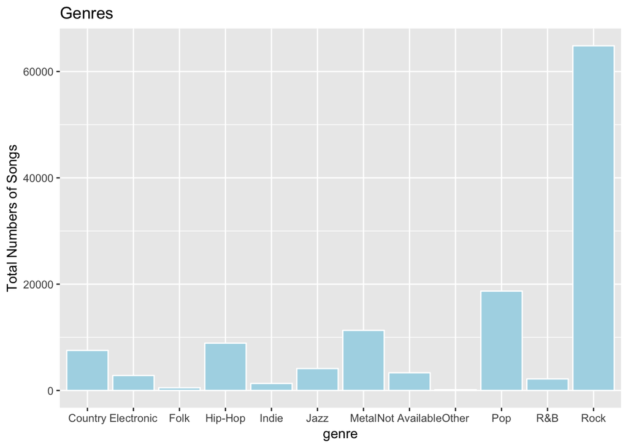

#### What’s the most common word?

In order to conduct sentiment analysis, I have to dig deeper into the lyrcis of the songs. I calculate the number of presence of each word. The result turns out to be that ‘love’ is the most popular word. If we look further into the top 5 popular words, 2 among 5 are obvious positive words, which are ‘love’ and ‘baby’, while ‘ill’ is a negative word. And the last two words, ‘time’ and ‘youre’, are neutral sentiment words according to my common sense.

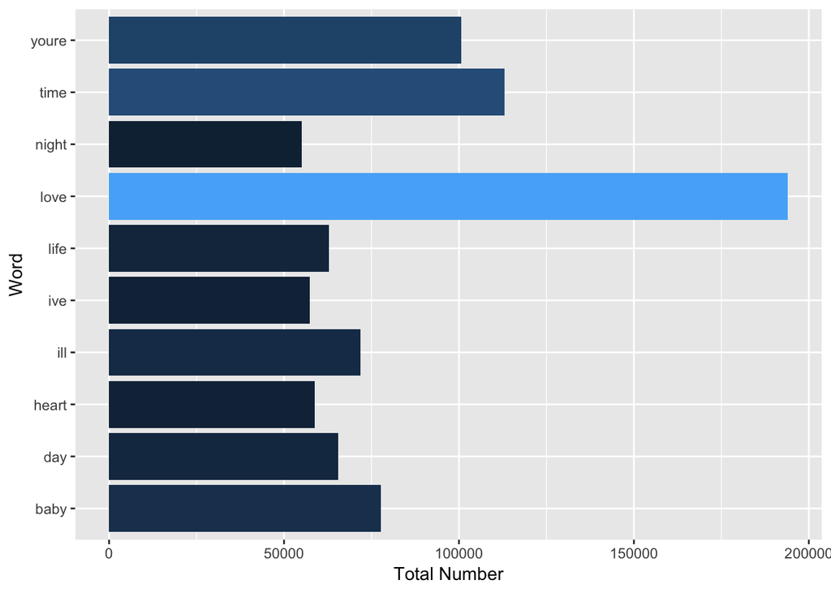

I also plot a word cloud for elegant visualization.

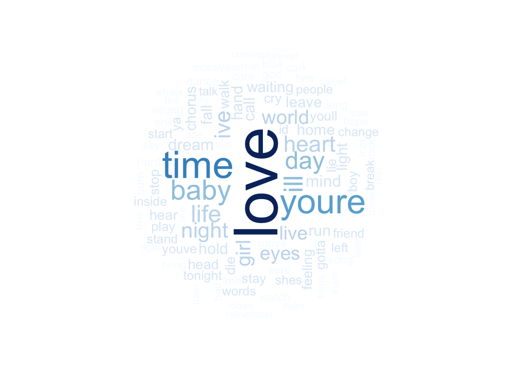

## Most common words in each music genre

After knowing the most common words for the entire songs with different music genres. I want to know that for each individual music genre, what are the most common words. So I select the top 6 music genres with the most number of songs,which are rock, pop, metal, hip-hop, country and jazz respectively. And I calculate the frequency of top 10 common words in each music genre and plot the word cloud for each genre.

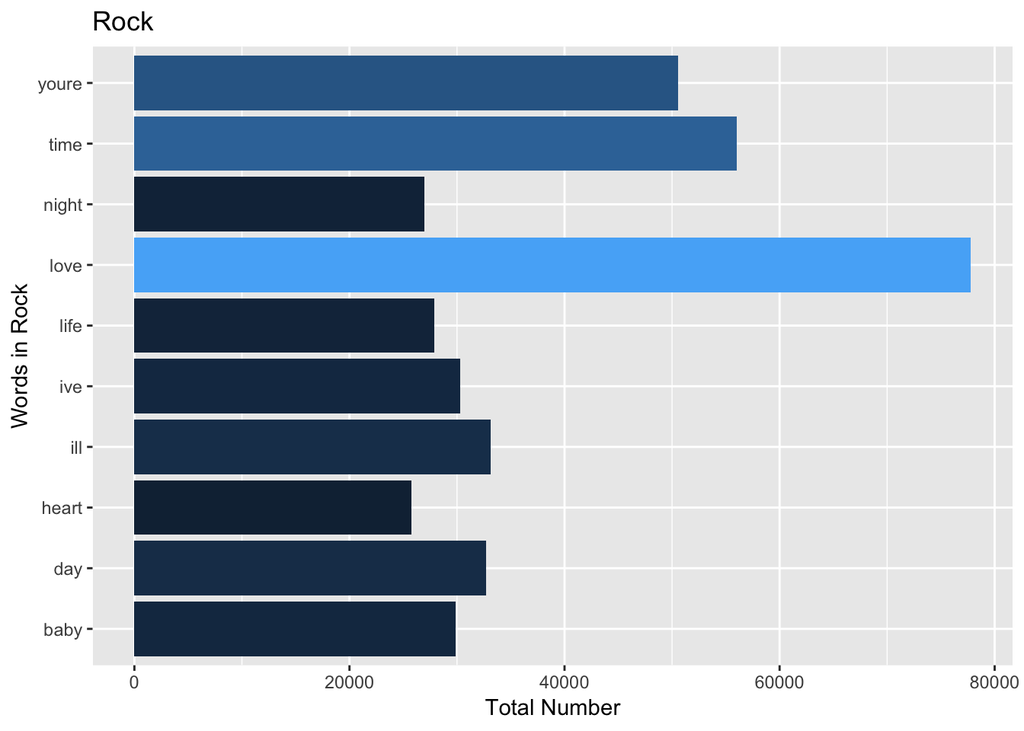

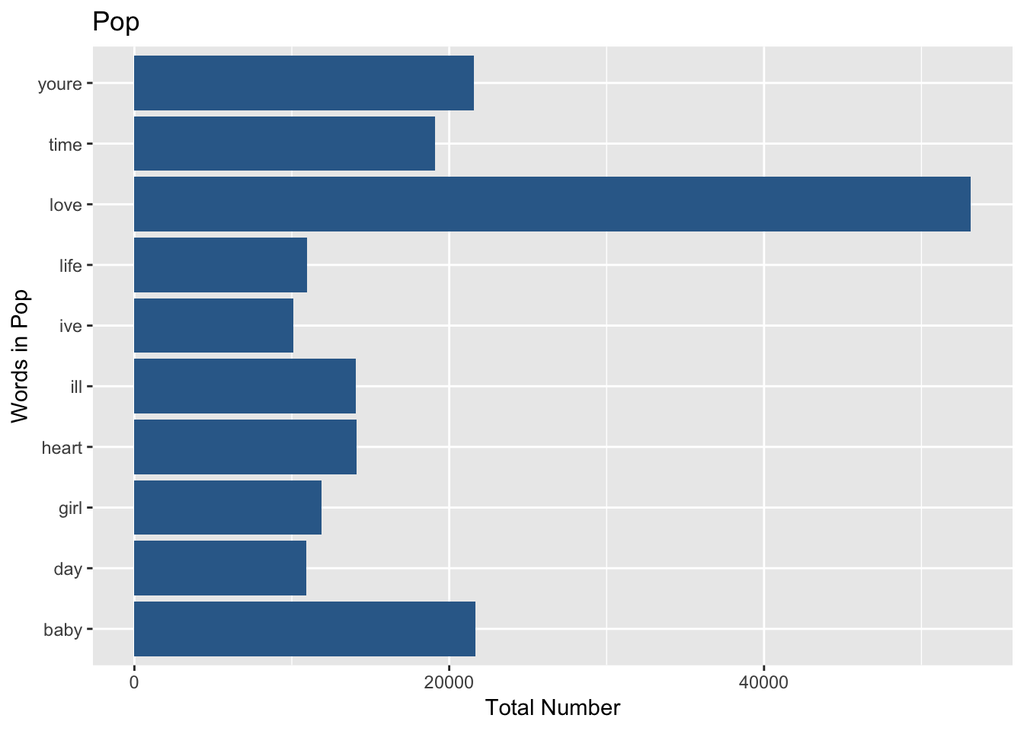

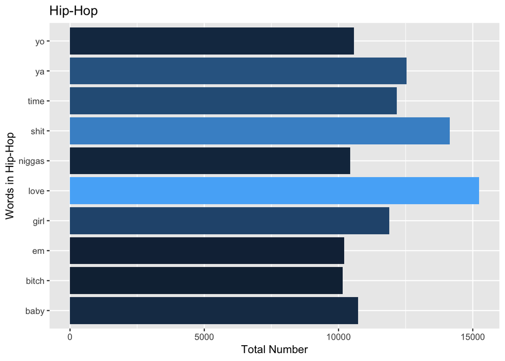

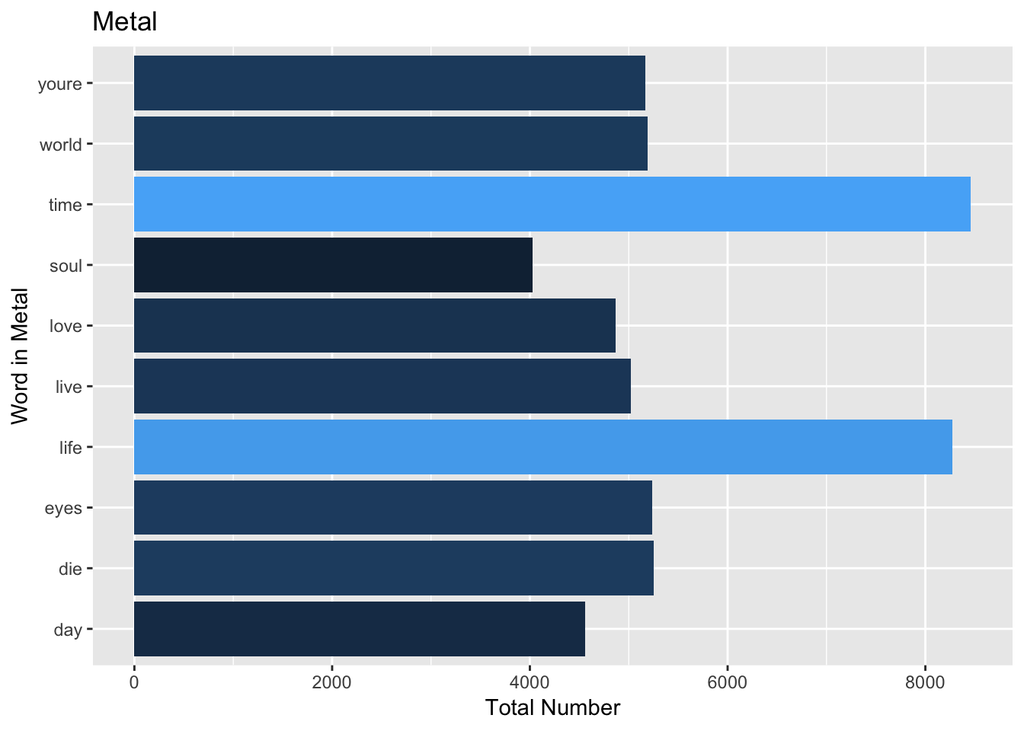

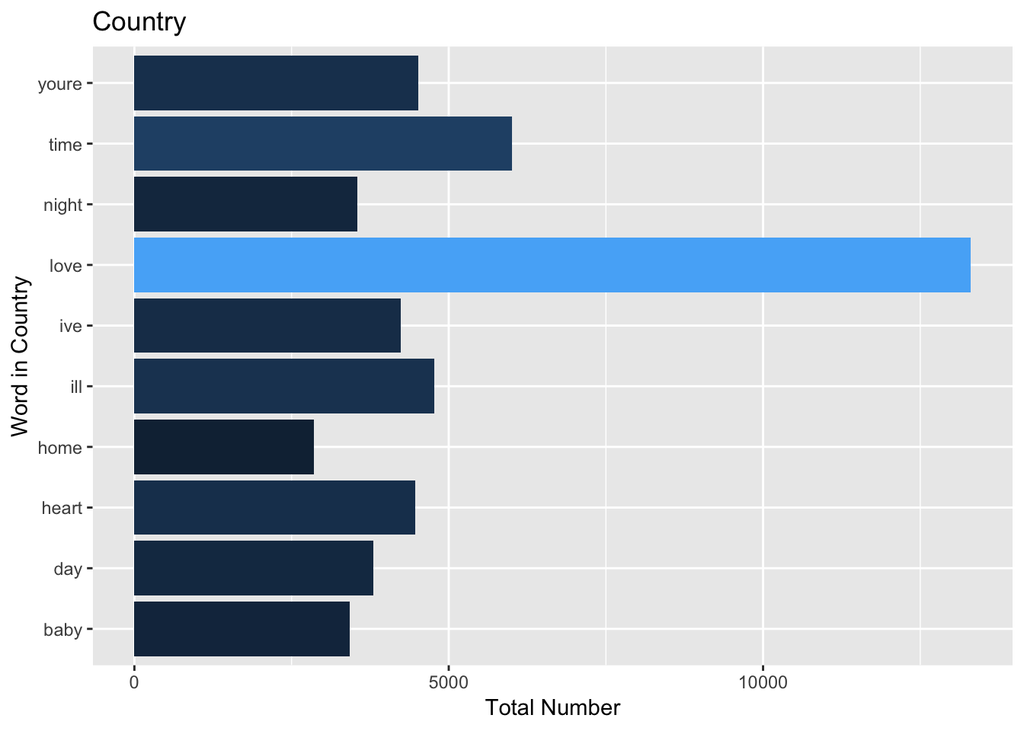

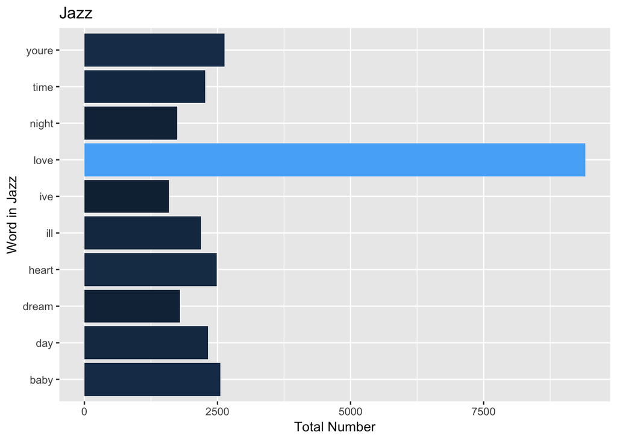

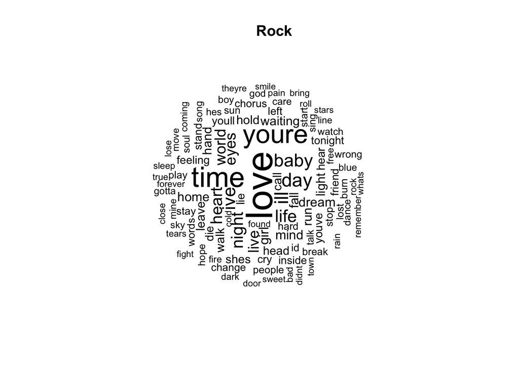

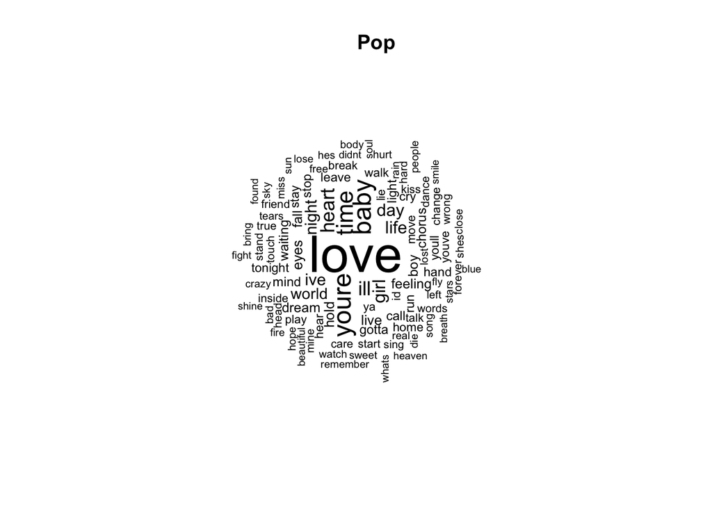

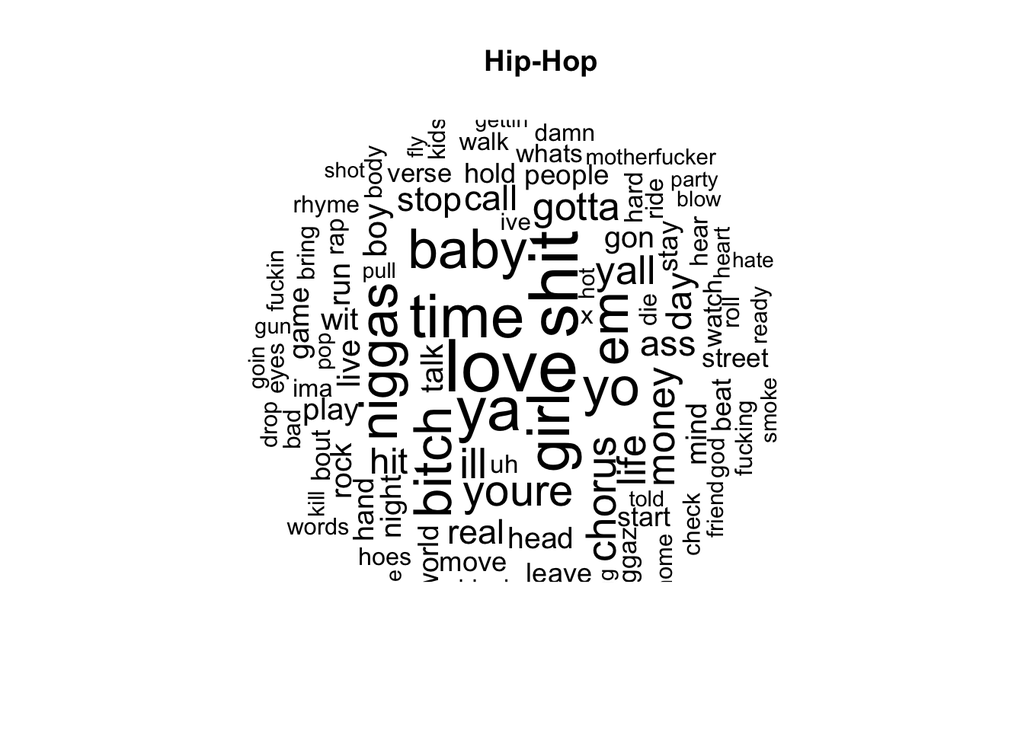

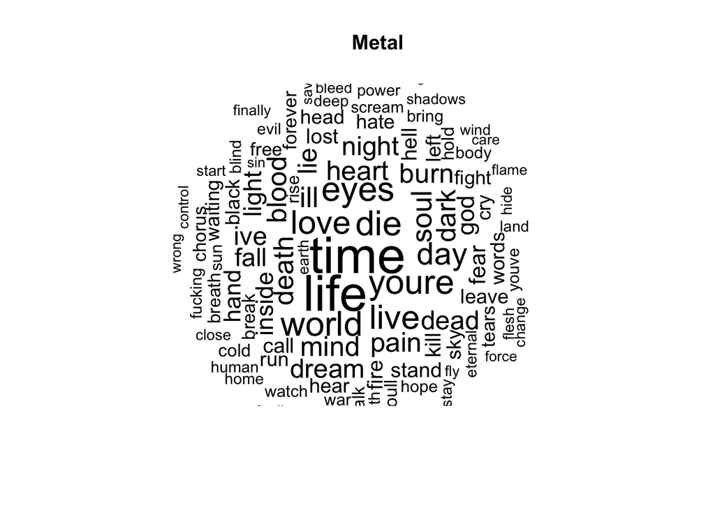

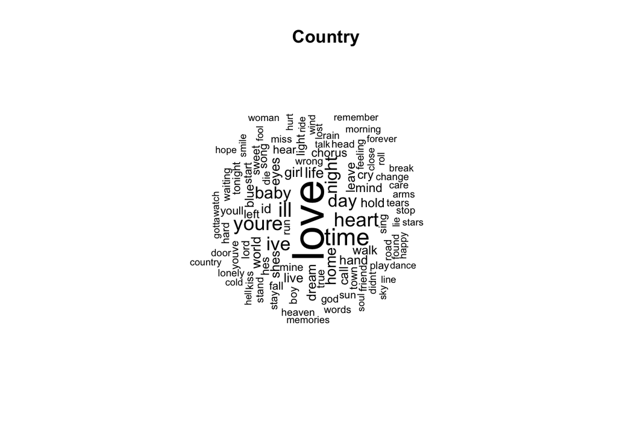

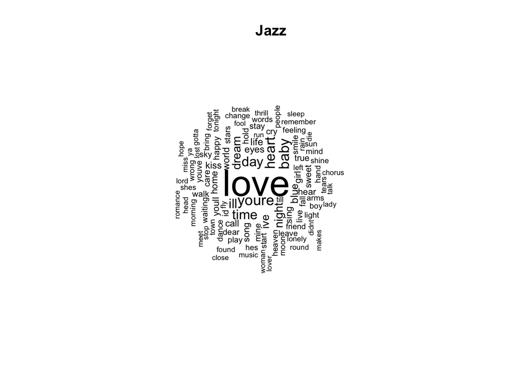

## Sentiment Analysis

For further analysis, I use the ‘bing’ lexicon. It classifies words in a binary trend into positive and negative categories. I also plot the word cloud for the most common positive and negative words.

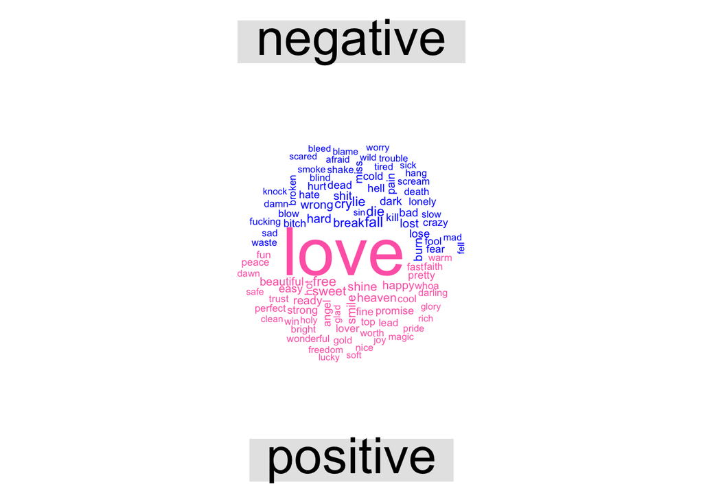

So I do the further research. I plot the frequency plot for both positive and negative words. As I said before, except the word ‘love’, the other words have similar frequency. I think the reason for this phenomenon is that the most popular topic for lyrics composing is love story. Although love itself is a positive word, when we form sentences with words, we need verbs and adjectives as well. ‘Sad love story’ and ‘sweet love’ express total contrast sentiment. So we cannot only decide the sentiment of each music genre by a few common words, instead we should take all words into consideration.

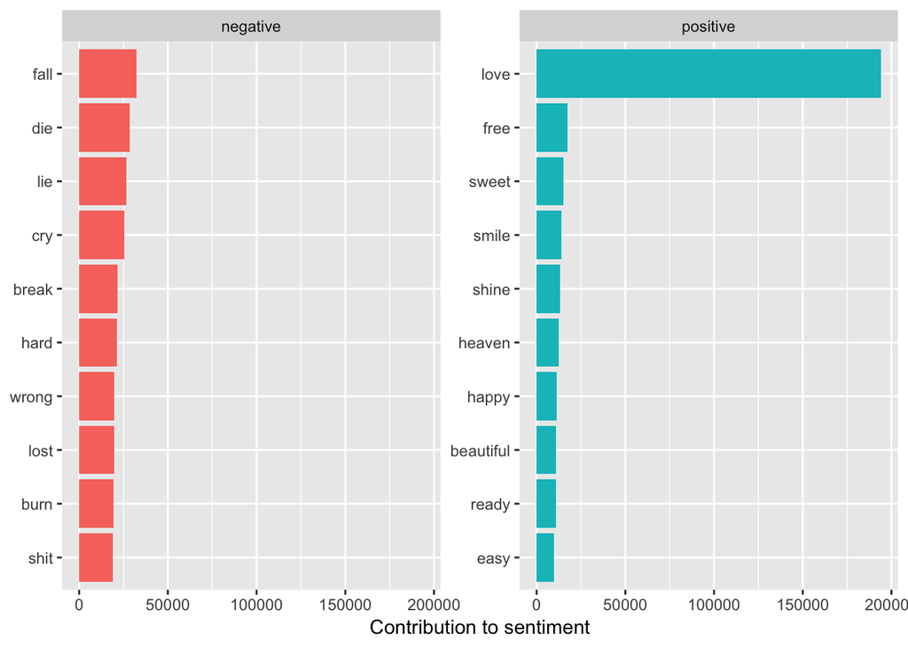

For this purpose, I conclude the scoring methods for the sentiment of words, and calcualte the average score for each music genre. This time, I use the AFINN lexicon, which assigns words with a score that runs between -5 and 5, with negative scores indicating negative sentiment and positive scores indicating positive sentiment.

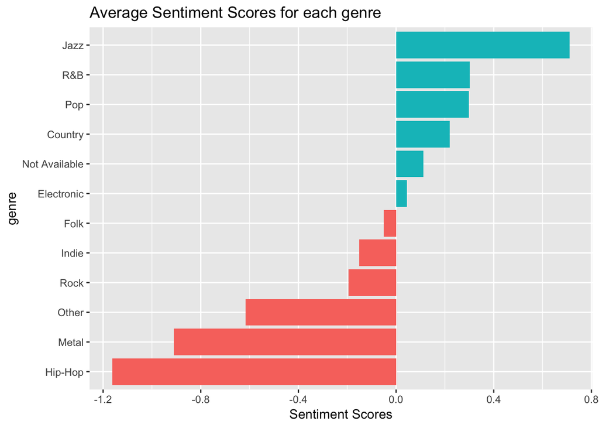

According to the frequency plot, music genres with negative sentiment scores, such as hip-hop, metal and rock are constant with our common sense. But for those with positive scores, the result is surprising. Jazz music receives the highest score! I know that jazz music will receive positive score according to previous analysis, but I do not expect that it has the highest score.

Let’s look again at the word cloud of jazz. The most common words are love,baby,heart, dream, kiss. And after viewing the table below, we can further confirm that jazz music actually has a positive sentiment!

So next time when speaking of Jazz, do not correlate it with Blues or sadness!

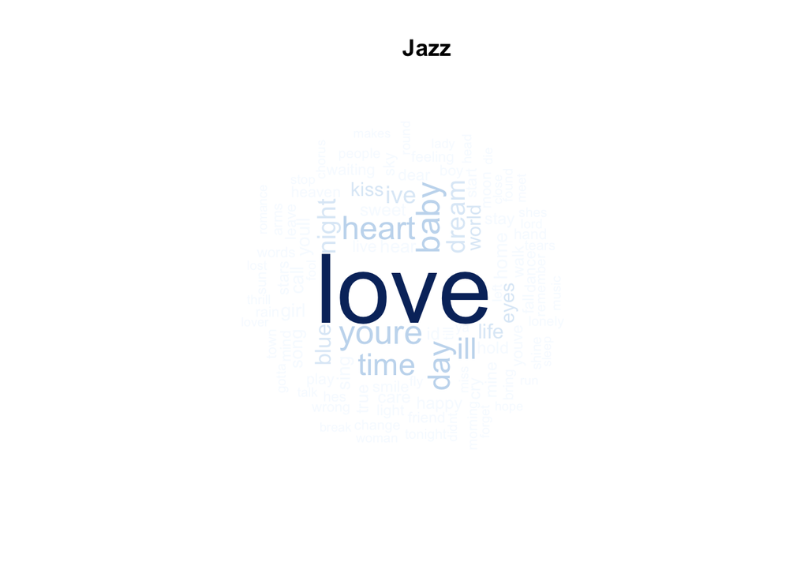

| genre | value | n |
| --- | --- | --- |
| Jazz | 3 | 13115 |
| Jazz | -2 | 10178 |
| Jazz | 2 | 9903 |
| Jazz | 1 | 6871 |
| Jazz | -1 | 5432 |
| Jazz | -3 | 2568 |
| Jazz | 4 | 1066 |
| Jazz | -4 | 316 |
| Jazz | -5 | 70 |
| Jazz | 5 | 4 |

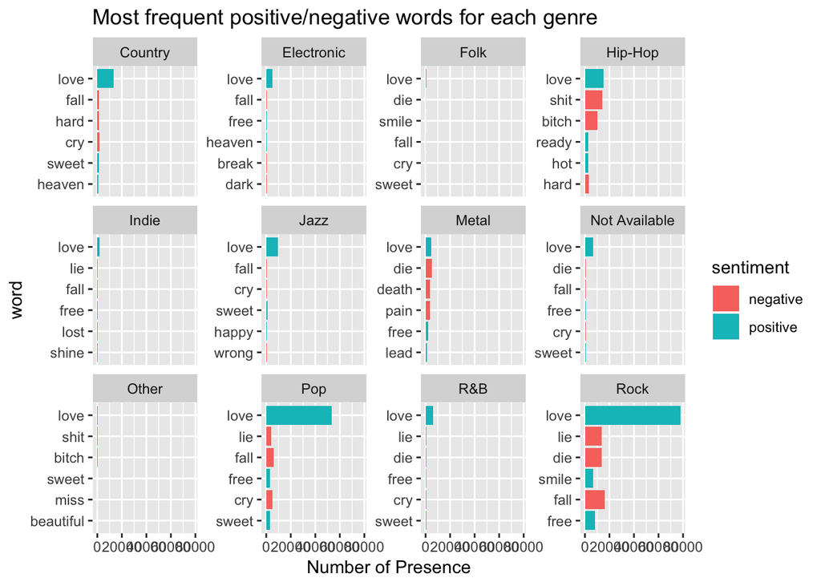

## Summary

By conducting sentiment analysis on song lyrics, we can obtain the following results:

- The most positive music genre is jazz(which is surprising!), followed by R&B, pop, country and eletronic.
- The most negative music genre is hip-hop, followed by metal, rock, indie and folk.
- Love is the most common word in all music genres except metal music.

## Inference

Julia Silge and David Robinson.2019.Text Mining with R.